# Human Performance

Sebastian Deri

[return to overview page]

In this section, I examine the accuracy of humans in truth and lie detection. To do this, I first needed people to judge the statements in our corpus. This was done with the help of three research assistants (Alexis Levine, Emem-Esther Ikpot, and Catherine Seita). I describe the procedure by which they rendered judgments in more detail below. This is followed by an analysis of their performance.

# Procedure

To begin, I randomly sorted the full set of 5,004 statements. I then divided this randomly sorted list of statements into three non-overlapping sets. I assigned one RA to each given segment. And I asked them go through the statements within their segment, one statement at a time. For each statement, they were asked to make two judgments. First, they made a binary judgment, a guess, about whether the statement was a truth or a lie. Second, they assessed how confident they were in their guess. The research assistants assessed their confidence by responding to the question “How confident are you in your guess?”, to which they could pick one of five responses: “0 = Not at all confident; 1 = Slightly confident; 2 = Somewhat confident; 3 = Fairly confident; 4 = Very confident”.

They were given the following general instruction about how they should orient their guessing.

> “Each of these statements represent a person’s response to a question that was asked of them. Sometimes those people responded to the question truthfully (i.e. by telling the truth) and sometimes they responded to the question untruthfully (i.e. by telling a lie).

> We would like for you to go through each of these statements, one at a time. First, read the statement thoroughly. And then, give us your best guess as to whether that statement is true (i.e. a case where the person responded to the question by telling the truth) or that statement is a lie (i.e. a case where the person responded to the question by telling a lie). Then, move on to the next statement and do the same.

> For each statement, you may make this guess on whatever basis you choose (i.e. on intuition and “gut” feeling, careful deliberation, or any other basis of deciding). What is simply most important is that you give us your best guess as to what you think is more likely - that the person’s statement is a truth or a that the person’s statement is a lie."

Research assistants recorded their responses in an excel sheet, pictured below.

[figure not shown]

Note that participants were not given any information about the questions to which each statement was a response. They simply read the statements and rendered their guesses. This was done so that any eventual comparison between human and computer performance would be on more equal footing. The computer models I have built and the primary additional ones I plan to build do not take into account any information about the question to which statements are a response. That is, the models do not include anything like an indicator variable for each question, a question by feature interaction term for predictors, a hierarchical model structure which factors in question or anything else whereby the model would account for the different question to which statements are a response. As far as the computer knows, there are just statements. (In later analysis, I do plan on building models that do account for each question.) Because the models do not account for questions, it seemed only fair that humans should not get any information about questions either.

As of the time of this writing, the research assistants did not render a judgment for each of the 5,004 statements. However, over 3,000 statements were evaluated, providing a solid basis to start the analysis, with which I now proceed.

# Packages

Again, I will start by loading relevant packages.

```r
# before knitting: message = FALSE, warning = FALSE
library(tidyverse) # cleaning and visualization
library(ggthemes) # visualization
library(xlsx) # reading in excel file
library(caret) # for confusionMatrix() function
library(skimr) # for dope ass summary stats
```

# Load Data

First, I will load in the excel sheets on which each of the research assistants recorded their responses. (And also another file which contains some other useful information about each statement – namely, the actual ground truth for each statement, which we’ll need to assess performance.)

```r
# load in guesses from RAs
stats_emem <-
  read.xlsx("guesses_EMEM.xlsx",
            sheetIndex = 1)


stats_catherine <-
  read.xlsx("guesses_CATHERINE.xlsx",
            sheetIndex = 1)

stats_lexi <-
  read.xlsx("guesses_LEXI.xls",
            sheetIndex = 1)

# load data frame that has stat_id connected to grd_truth
load("stats_clean.Rda")
```

# Clean Data

In this section, I clean up and format the research assistant’s responses. I then combine these responses into one data object. The entries in this data object are printed below.

(A note: there were actually a set of 100 statements for which two research assistants, Emem and Catherine, both registered responses. This was not an accident. Rather, the purpose was to use this to later examine consistency in guessing between different guessers. For the main analyses, these 100 statements are excluded.)

```r
# rename columns in emem file
stats_emem_clean <-
  stats_emem %>%
  select(stat_id, 5, 6) %>%
  rename_at(2, ~ "predict") %>%
  rename_at(3, ~ "conf") %>%
  mutate(predict = tolower(trimws(predict))) %>%
  filter(!is.na(predict)) %>%
  mutate(person = "emem") %>%
  dplyr::mutate(order = row_number())

# rename columns in catherine file
stats_catherine_clean <-
  stats_catherine %>%
  select(stat_id, 5, 6) %>%
  rename_at(2, ~ "predict") %>%
  rename_at(3, ~ "conf") %>%
  mutate(predict = tolower(trimws(predict))) %>%
  filter(!is.na(predict)) %>%
  mutate(person = "catherine") %>%
  dplyr::mutate(order = row_number())

# rename columns in lexi file
stats_lexi_clean <-
  stats_lexi %>%
  select(stat_id, 4, 5, Participant) %>%
  rename_at(2, ~ "predict") %>%
  rename_at(3, ~ "conf") %>%
  mutate(predict = tolower(trimws(predict))) %>%
  filter(!is.na(predict)) %>%
  dplyr::rename(person = Participant) %>%
  mutate(person = trimws(as.character(person))) %>%
  mutate(person = case_when(person == "1" ~ "lexi",
                            person != "1" ~ person)) %>%
  filter(person == "lexi") %>% # only take the guesses from lexi (not the p's ran)
  dplyr::mutate(order = row_number())

# combine files
stats_guess <-
  bind_rows(stats_emem_clean,
            stats_catherine_clean,
            stats_lexi_clean)

# find statements for which multiple people might have registered guesses
overlap_stat_id <-
  c(intersect(stats_emem_clean$stat_id, stats_catherine_clean$stat_id), # has overlap
    intersect(stats_emem_clean$stat_id, stats_lexi_clean$stat_id),
    intersect(stats_catherine_clean$stat_id, stats_lexi_clean$stat_id))

# remove any rows which have been answered by multiple people
stats_guess <-
  stats_guess %>%
  filter(!(stat_id %in% overlap_stat_id))

# join files with ground truth data
stats_guess <-
  stats_guess %>%
  left_join(y = (stats_clean %>% select(stat_id, grd_truth)),
            by = "stat_id") %>%
  select(stat_id,
         grd_truth,
         everything()) %>%
  mutate(predict = as.factor(predict))

# print resulting data frame
stats_guess
```

| stat_id | grd_truth | predict | conf | person | order |
| --- | --- | --- | --- | --- | --- |
| 4919 | lie | truth | 3 | emem | 101 |
| 3534 | lie | lie | 3 | emem | 102 |
| 1411 | truth | truth | 4 | emem | 103 |
| 3749 | lie | truth | 4 | emem | 104 |
| 3848 | lie | truth | 3 | emem | 105 |
| 274 | truth | truth | 2 | emem | 106 |
| 3672 | lie | lie | 3 | emem | 107 |
| 1917 | truth | truth | 3 | emem | 108 |
| 4587 | lie | truth | 4 | emem | 109 |
| 3703 | lie | truth | 3 | emem | 110 |

[output cut: 3653 more lines]

# Lies From Each Person

First, let’s just look at how many statements were evaluated. We see that truth-lie predictions (and confidence judgments) were made for 3,663 statements – with 1,605 of these guesses from Catherine, 1299 from Emem, and 759 from Lexi.

```r
stats_guess %>%
  dplyr::count(person) %>%
  arrange(desc(n))
```

| person | n |
| --- | --- |
| catherine | 1605 |
| emem | 1299 |
| lexi | 759 |

# Overall Performance

Now let’s examine how well the human guessers performed, by comparing their guesses to reality. When we do this, we see that their overall accuracy was 55.5% (2033 correct out of 3,663 guesses), which is significantly higher than 50%, p < 0.001 (using an exact binomial test). Interestingly, sensitivity (70.0%), i.e. accuracy among truths, is much higher than specificity (41.0%), i.e. accuracy among lies; indeed this difference is significant, chi-squared = 311.15, p < 0.001. While sensitivity was significantly higher than 50%, p <0.001 (binomial test), sensitivity was actually significant below 50%, p < 0.001 (binomial test). These asymmetry in correctly identify truths as truth compared to correctly identifying lies as lies is found consistently in the lie detection literature (Bond & DePaulo, 2006; Levine, Park, & McCornack, 1999). For some reason, people are better at idenifying truths than lies. I am not aware of any definitive account of why this occurs. But it is my hypothesis that in the course of natural speech people encounter many more truthful statements than lies (imagine how chaotic and unpleasant communication would be if 50% of the things people said were lies). And thus people are calibrated toward a base rate where statements are much more likely to be true than untrue, and so tend to err on the side of assuming that a communication is truthful unless there is some strong reason to believe otherwise. (Note that nowhere in the instructions or materials were participants told that the ratio of truths to lies in this data set was 50:50. Nor did participants receive feedback on their guesses after each one was made.)

```r
# save confusion matrix with performance stats
human_conf <-
  confusionMatrix(data = stats_guess$predict,
                  reference = stats_guess$grd_truth,
                  positive = "truth")

# print confusion matrix
human_conf
```

```
## Confusion Matrix and Statistics
##
##           Reference
## Prediction  lie truth
##      lie    751   549
##      truth 1081  1282
##
##                Accuracy : 0.555
##                  95% CI : (0.5387, 0.5712)
##     No Information Rate : 0.5001
##     P-Value [Acc > NIR] : 1.654e-11
##
##                   Kappa : 0.1101
##  Mcnemar's Test P-Value : < 2.2e-16
##
##             Sensitivity : 0.7002
##             Specificity : 0.4099
##          Pos Pred Value : 0.5425
##          Neg Pred Value : 0.5777
##              Prevalence : 0.4999
##          Detection Rate : 0.3500
##    Detection Prevalence : 0.6451
##       Balanced Accuracy : 0.5550
##
##        'Positive' Class : truth
##
```

```r
# calculate relevant values for binomial test
correct = human_conf$table[1] + human_conf$table[4]
total = sum(human_conf$table)

# examine overall accuracy with exact binomial test
binom.test(x = correct,
           n = total,
           p = 0.5,
           alternative = "two.sided",
           conf.level = 0.95)
```

```
##
##  Exact binomial test
##
## data:  correct and total
## number of successes = 2033, number of trials = 3663, p-value =
## 2.957e-11
## alternative hypothesis: true probability of success is not equal to 0.5
## 95 percent confidence interval:
##  0.5387408 0.5711904
## sample estimates:
## probability of success
##              0.5550096
```

```r
# calculate values relevant for test
truth_correct = human_conf$table[4]
truth_total = human_conf$table[3] + human_conf$table[4]
lie_correct = human_conf$table[1]
lie_total = human_conf$table[1] + human_conf$table[2]

# calulate some other relevant values (for later use, in both visualization and later tests)
# calculate values relevant for test
total_truth_guesses = human_conf$table[2] + human_conf$table[4]
total_lie_guesses = human_conf$table[1] + human_conf$table[3]


# conduct actual test
# (more info: https://www.r-bloggers.com/comparison-of-two-proportions-parametric-z-test-and-non-parametric-chi-squared-methods/)
prop.test(x = c(truth_correct, lie_correct),
          n = c(truth_total, lie_total),
          alternative = "two.sided",
          conf.level = 0.95)
```

```
##
##  2-sample test for equality of proportions with continuity
##  correction
##
## data:  c(truth_correct, lie_correct) out of c(truth_total, lie_total)
## X-squared = 311.15, df = 1, p-value < 2.2e-16
## alternative hypothesis: two.sided
## 95 percent confidence interval:
##  0.2588994 0.3215593
## sample estimates:
##    prop 1    prop 2
## 0.7001638 0.4099345
```

```r
# binom test comparing sensitivity to chance
binom.test(x = truth_correct,
           n = truth_total,
           p = 0.5,
           alternative = "two.sided",
           conf.level = 0.95)
```

```
##
##  Exact binomial test
##
## data:  truth_correct and truth_total
## number of successes = 1282, number of trials = 1831, p-value <
## 2.2e-16
## alternative hypothesis: true probability of success is not equal to 0.5
## 95 percent confidence interval:
##  0.6785953 0.7210892
## sample estimates:
## probability of success
##              0.7001638
```

```r
# binom test comparing specificity to chance
binom.test(x = lie_correct,
           n = lie_total,
           p = 0.5,
           alternative = "two.sided",
           conf.level = 0.95)
```

```
##
##  Exact binomial test
##
## data:  lie_correct and lie_total
## number of successes = 751, number of trials = 1832, p-value =
## 1.287e-14
## alternative hypothesis: true probability of success is not equal to 0.5
## 95 percent confidence interval:
##  0.3872998 0.4328581
## sample estimates:
## probability of success
##              0.4099345
```

# Overall Performance (Visualization)

Below, I have simply visualized the basic performance statistics from above. In addition to seeing again the overall accuracy is above chance, while sensitivity and specificity are far apart with the former above 50% and the latter below, we also see both precision (accuracy rate when guessing that a statement is true) and negative preditive value (accuracy rate when guessing that a statement is false) are above 50% (p<0.001 for both, by exact binomial test). Negative predictive value appears to be slightly higher than precision, although this different is just barely below theshold of significance, chi-squared = 4.06, p = 0.044, so it might not prove a robust effect. Speculatively, it might be that negative predictive value is higher than precision because people guess that way fewer statements are lies than truths (1300 v. 2363). Thus, they may only make a guess that a statement is a lie when they are really sure of it – and they may be more accurate when they are more sure. Nevertheless, more data is needed to speak to this definitively.

```r
# -----------------------------------------------------------------------------
# STEP 1: make df to store results (organize with same columns as computer model results df's)
# part a: create names of results to store
result_cols <- c("model_type", "round", "accuracy", "accuracy_LL", "accuracy_UL",
                 "sensitivity", "specificity", "precision", "npv", "n")

# part b: create matrix
results <-
  matrix(nrow = 1,
         ncol = length(result_cols))

# part c: actually name columns in results marix
colnames(results) <- result_cols

# part d: convert to df (so multiple variables of different types can be stored)
results <- data.frame(results)

# -----------------------------------------------------------------------------
# STEP 2: actually store results
# model type
results[1, 1] <- "human"
# round
results[1, 2] <- 1
# accuracy
results[1, 3] <- human_conf$overall[1]
# accuracy LL
results[1, 4] <- human_conf$overall[3]
# accuracy UL
results[1, 5] <- human_conf$overall[4]
# sensitivity
results[1, 6] <- human_conf$byClass[1]
# specificity
results[1, 7] <- human_conf$byClass[2]
# precision
results[1, 8] <- human_conf$byClass[3]
# negative predictive value
results[1, 9] <- human_conf$byClass[4]
# sample size (of test set)
results[1, 10] <- sum(human_conf$table)
```

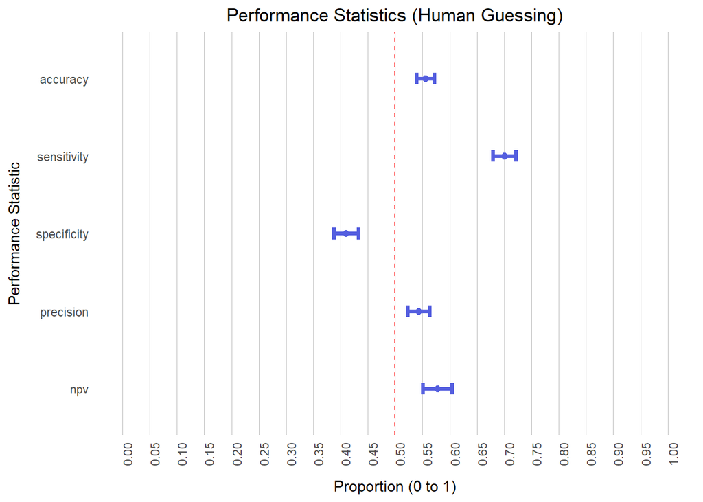

```r
# -----------------------------------------------------------------------------
# STEP 3: actual visualization
# step a: create df to use for visualization
results_viz <-
  results %>%
  select(-model_type, -round, -n, -accuracy_LL, -accuracy_UL) %>%
  gather(key = "perf_stat",
         value = "value") %>%
  mutate(value = as.numeric(value))

# step b: visualize results
ggplot(data = results_viz,
  aes(x = perf_stat,
           y = value)) +
geom_point(size = 2,
           color = "#545EDF") +
geom_errorbar(aes(ymin = (value - 1.96*sqrt(value*(1-value)/c(results$n,
                                                              truth_total,
                                                              lie_total,
                                                              total_truth_guesses,
                                                              total_lie_guesses))),
                   ymax = (value + 1.96*sqrt(value*(1-value)/c(results$n,
                                                              truth_total,
                                                              lie_total,
                                                              total_truth_guesses,
                                                              total_lie_guesses)))),
              color = "#545EDF",
              width = 0.15,
              size = 1.25) +
geom_hline(yintercept = 0.5,
           linetype = "dashed",
           size = 0.5,
           color = "red") +
scale_y_continuous(breaks = seq(from = 0, to = 1, by = 0.05),
                   limits = c(0, 1)) +
scale_x_discrete(limits = rev(c("accuracy", "sensitivity", "specificity",
                            "precision", "npv"))) +
coord_flip() +
theme(panel.grid.major.x = element_line(color = "grey",
                                        size = 0.25),
      panel.grid.minor.x = element_blank(),
      panel.grid.major.y = element_blank(),
      panel.background = element_blank(),
      axis.ticks = element_blank(),
      plot.title = element_text(hjust = 0.5),
      axis.title.y = element_text(margin =
                                    margin(t = 0, r = 10, b = 0, l = 0)),
      axis.title.x = element_text(margin =
                                    margin(t = 10, r = 00, b = 0, l = 0)),
      axis.text.x = element_text(angle = 90)) +
labs(title = "Performance Statistics (Human Guessing)",
     x = "Performance Statistic",
     y = "Proportion (0 to 1)")
```

```r
# calculate values relevant for test
total_truth_guesses = human_conf$table[2] + human_conf$table[4]
total_lie_guesses = human_conf$table[1] + human_conf$table[3]

# conduct actual test
binom.test(x = truth_correct, # variable created in earlier chunk
           n = total_truth_guesses,
           p = 0.5,
           alternative = "two.sided",
           conf.level = 0.95)
```

```
##
##  Exact binomial test
##
## data:  truth_correct and total_truth_guesses
## number of successes = 1282, number of trials = 2363, p-value =
## 3.844e-05
## alternative hypothesis: true probability of success is not equal to 0.5
## 95 percent confidence interval:
##  0.5221901 0.5627657
## sample estimates:
## probability of success
##              0.5425307
```

```r
# conduct actual test
binom.test(x = lie_correct, # variable created in earlier chunk
           n = total_lie_guesses,
           p = 0.5,
           alternative = "two.sided",
           conf.level = 0.95)
```

```
##
##  Exact binomial test
##
## data:  lie_correct and total_lie_guesses
## number of successes = 751, number of trials = 1300, p-value =
## 2.329e-08
## alternative hypothesis: true probability of success is not equal to 0.5
## 95 percent confidence interval:
##  0.5503075 0.6047251
## sample estimates:
## probability of success
##              0.5776923
```

```r
prop.test(x = c(truth_correct, lie_correct),
          n = c(total_truth_guesses, total_lie_guesses),
          alternative = "two.sided",
          conf.level = 0.95)
```

```
##
##  2-sample test for equality of proportions with continuity
##  correction
##
## data:  c(truth_correct, lie_correct) out of c(total_truth_guesses, total_lie_guesses)
## X-squared = 4.057, df = 1, p-value = 0.04399
## alternative hypothesis: two.sided
## 95 percent confidence interval:
##  -0.069289651 -0.001033601
## sample estimates:
##    prop 1    prop 2
## 0.5425307 0.5776923
```

# Save

With this, we are done with the primary analysis of human truth-lie detection performance. I will save the main results and data files we have created.

```r
# saved bound together human guesses
save(stats_guess,
     file = "stats_guess.Rda")

# rename results df, to be particular to this model type (for disambiguation later)
results_human <- results

# clear results variable
rm(results)

# save results in Rda file
save(results_human,
     file = "results_human.Rda")
```

# OTHER ANALYSES

In this section, I would just like to cursorily breeze through some non-primary analyses, which I’m nevertheless wondering about. I won’t do formal tests for statistical inference. Rather, I just want to quickly visually inspect a few things for any obvious patterns.

## Performance by Person

First, I want to just quickly get a sense of how performance various by person. To this, I will examine the five main performance measures (overall accuracy, sensitivity, specificity, precision, and negative predictive value) for each of the three research assistants.

### Performance by Person (Store Results)

Below, I compute and store the performance results for each of research assistants.

```r
# -----------------------------------------------------------------------------
# STEP 1: create vector of names of guessers
people <- c("lexi", "emem", "catherine")

# -----------------------------------------------------------------------------
# STEP 2: initialize data frame to save results
human_perf <-
  matrix(ncol = 6,
         nrow = length(people))
# name columns
colnames(human_perf) <- c("person", "accuracy", "sensitivity", "specificity", "precision", "npv")

# convert to df
human_perf <- data.frame(human_perf)

# -----------------------------------------------------------------------------
# STEP 3: loop through and store performance stats
counter = 0
for (person_i in people) {
  # increment counter
  counter = counter + 1

  # generate confusion matrix for this person
  conf_i <-
    confusionMatrix(data = subset(stats_guess,
                                  person == person_i)$predict,
                    reference = subset(stats_guess,
                                       person == person_i)$grd_truth,
                    positive = "truth")

  # store current person in results matrix
  human_perf[counter, 1] <- person_i

  # store overall accuracy stats
  human_perf[counter, 2] <- conf_i$overall[1]

  # store sensitivity, specificity, precision, NPV
  human_perf[counter, 3:6] <-  c(conf_i$byClass[1], conf_i$byClass[2],
                         conf_i$byClass[3], conf_i$byClass[4])
}
```

### Performance by Person (Results)

Below, the resultant data object – with each of the five major performance statistics for each research assistant – is printed. It’s hard to compare and gain insight from the raw numbers (at least for me), so let’s instead visualize this.

```r
human_perf
```

| person | accuracy | sensitivity | specificity | precision | npv |
| --- | --- | --- | --- | --- | --- |
| lexi | 0.5691700 | 0.8375635 | 0.2794521 | 0.5564924 | 0.6144578 |
| emem | 0.5511932 | 0.7637195 | 0.3343701 | 0.5392896 | 0.5810811 |
| catherine | 0.5514019 | 0.5774648 | 0.5266990 | 0.5362663 | 0.5680628 |

### Peformance by Person (Visualize)

From quick visual inspection, my main takeaway is that overall accuracy is pretty similar across people. But sensitivity and specificity vary widely. One RA (Lexi) has a wide gap between her ability to correctly identify truths as truths (>80%) and her ability to correctly identify lies as lies (<30%). This likely comes from making way more guesses of truths that lies. Meanwhile other RAs (e.g. Catherine) are more well balanced in their ability to identify truths as truths (~57%) and lies as lies (~52%). It is interesting that these wide differences in guessing patterns lead to similar overall performance. It is also interesting to speculate as to what might be the source of these differences. Are people with higher sensitivity scores more trusting (and as a result trust that more statements are true), and people with higher specificity scores more skeptical and suspicious (and as a result are more likely to believe that a statement might be a lie)? Are people with closer sensitivity and specificity scores (assuming some baseline level of performance; i.e. not just that both are very low) in some sense more “discerning”? Are these differences stable? Are they due the communicative environments in which people are immersed, or individual talents? It might be worth examining any of these questions more closely, as well as combing the existing literature for insights.

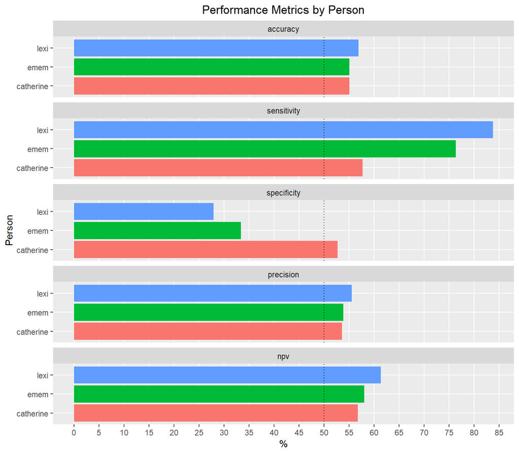

```r
human_perf %>%
  gather(key = "perf_stat",
         value = "result",
         accuracy, sensitivity, specificity, precision, npv) %>%
  mutate(perf_stat = factor(perf_stat,
                            levels = c("accuracy", "sensitivity", "specificity", "precision", "npv"))) %>%
  ggplot(aes(x = person,
             y = round(result * 100, 1),
             fill = person)) +
  geom_col() +
  coord_flip() +
  facet_wrap( ~ perf_stat,
            ncol = 1) +
  scale_y_continuous(breaks = seq(from = 0, to = 100, by = 5)) +
  geom_hline(yintercept = 50,
             color = "black",
             linetype = "dotted",
             size = 0.5) +
  labs(title = "Performance Metrics by Person",
       x = "Person",
       y = "%") +
  guides(fill = FALSE) +
  theme(plot.title = element_text(hjust = 0.5),
        panel.grid.minor.x = element_blank())
```

## Confidence Calibration

Another relationship I wanted to briefly examine in the data is the one between accuracy and confidence. Because each guess was accompanied by a confidence rating, it is possible to examine whether greater confidence in a guess actually translated into greater accuracy.

### Confidence Calibration (Tabulate)

```r
# count number of TP, TN, FP, FN
stats_guess_keyed <-
  stats_guess %>%
  mutate(order_tens = floor(order / 10)) %>%
  mutate(outcome = case_when((predict == "truth") & (grd_truth == "truth") ~ "true_pos",
                             (predict == "truth") & (grd_truth == "lie") ~ "false_pos",
                             (predict == "lie") & (grd_truth == "lie") ~ "true_neg",
                             (predict == "lie") & (grd_truth == "truth") ~ "false_neg"))

# calculate perf stats at each confidence level
human_perf_conf <-
  stats_guess_keyed %>%
  group_by(conf, outcome) %>%
  dplyr::summarise(n = n()) %>%
  spread(key = outcome,
         value = n,
         fill = 0) %>%
  mutate(accuracy = (true_pos + true_neg) / (true_pos + true_neg + false_pos + false_neg),
         sensitivity = (true_pos) / (true_pos + false_neg),
         specificity = (true_neg) / (true_neg + false_pos),
         precision = (true_pos) / (true_pos + false_pos),
         npv = (true_neg) / (true_neg + false_neg),
         perc_pos = (true_pos + false_neg) / (true_pos + true_neg + false_pos + false_neg),
         total = true_pos + true_neg + false_pos + false_neg) %>%
  select(conf, total, everything())

# print results
human_perf_conf
```

| conf | total | false_neg | false_pos | true_neg | true_pos | accuracy | sensitivity | specificity | precision | npv | perc_pos |
| --- | --- | --- | --- | --- | --- | --- | --- | --- | --- | --- | --- |
| 0 | 626 | 199 | 109 | 207 | 111 | 0.5079872 | 0.3580645 | 0.6550633 | 0.5045455 | 0.5098522 | 0.4952077 |
| 1 | 674 | 77 | 243 | 101 | 253 | 0.5252226 | 0.7666667 | 0.2936047 | 0.5100806 | 0.5674157 | 0.4896142 |
| 2 | 875 | 145 | 271 | 178 | 281 | 0.5245714 | 0.6596244 | 0.3964365 | 0.5090580 | 0.5510836 | 0.4868571 |
| 3 | 952 | 107 | 285 | 194 | 366 | 0.5882353 | 0.7737844 | 0.4050104 | 0.5622120 | 0.6445183 | 0.4968487 |
| 4 | 536 | 21 | 173 | 71 | 271 | 0.6380597 | 0.9280822 | 0.2909836 | 0.6103604 | 0.7717391 | 0.5447761 |

## Confidence Calibration (Visualize)

I’ve visualized the results below. Along the x-axis are the confidence ratings. A separate line is drawn (in different colors) for each of the five performance statistics. Along the y-axis runs percentage. Just from this superficial look, there is some hint of a positive relationship between confidence ratings and performance, whereby performance (as measured by overall accuracy, sensitivity, precision, and negative predictive values) seems to be higher when people have higher confidence in their guesses. Although, this pattern seems notably different for specificity; that is, accuracy in correctly identifying lies as lies. If the data are to be believed, specificity is actually highest when participants are least confident in their guesses. Meanwhile, sensitivity is lowest when participants are least confident. This might suggest that when participants are least confident in their guesses, they could improve their accuracy by erring more towards guessing that a statement is a lie. Deeper and further analysis is needed to examine these relationships.

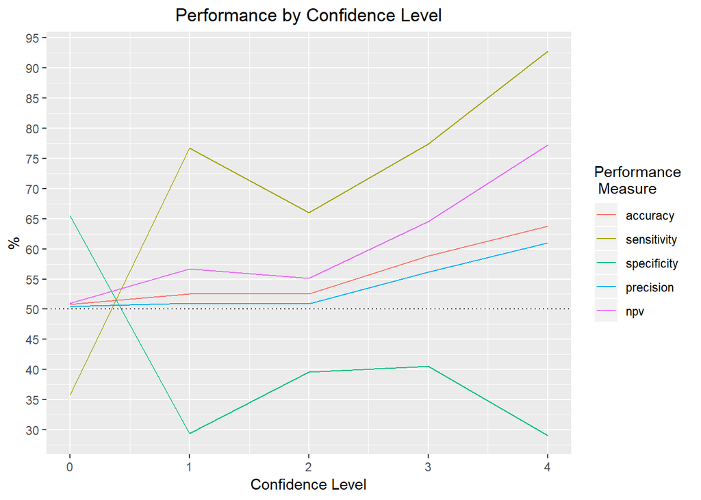

```r
human_perf_conf %>%
  gather(key = "perf_stat",
         value = "result",
         accuracy, sensitivity, specificity, precision, npv) %>%
  mutate(perf_stat = factor(perf_stat,
                            levels = c("accuracy", "sensitivity", "specificity", "precision", "npv"))) %>%
  ggplot(aes(x = conf,
             y = round(result * 100, 1),
             color = perf_stat)) +
  geom_line() +
  # geom_point(aes(size = total)) +
  geom_hline(yintercept = 50,
             color = "black",
             linetype = "dotted",
             size = 0.50) +
  scale_y_continuous(breaks = seq(from = 0, to = 100, by = 5)) +
  labs(title = "Performance by Confidence Level",
       x = "Confidence Level",
       y = "%",
       color = "Performance \n Measure") +
  theme(plot.title = element_text(hjust = 0.5))
```

## Performance by Order

Finally, although guessers did not receive feedback as they went along, I wanted to quickly visually examine whether people might have gotten better as they were going along. For each participant, I not only have their judgments for each statement, but the order in which they went through the statements. Thus, I can examine how performance varies as a function of how many statments participants had already rated. This is what I do below, in multiple ways.

(Note; for this analysis I added back in the 100 overlapping statements that both Emem and Catherine rated; as excluding them would alter the apparent order in which people responded to statements. This would be an especially notable exclusion here because, for both Emem and Catherine, these 100 statements were the very first 100 statements they evaluated. This is what I am doing in the code chunk just below.)

```r
# combine files again (with no later elimination of overlapping guesses)
stats_guess_full <-
  bind_rows(stats_emem_clean,
            stats_catherine_clean,
            stats_lexi_clean) %>%
  left_join(y = (stats_clean %>% select(stat_id, grd_truth)),
            by = "stat_id")
```

### Performance by Order (Groups of Ten)

Overall accuracy is either 0 or 100% when evaluating just one statement. Thus, it made sense to me to chunk the ordered statements together into equal sized groups. Of course, the size of these groups is arbitrary. I tried out two levels of granularity. Here statements are grouped into chunks of ten, i.e. we examining overall accuracy in the first chunk of 10 statements, followed by overall accuracy in the second chunk of 10 statements, and so on). This grouping size may be too granular, as the main thing that sticks out in the figure below is simply the high degree of variability as participants are going along, rather than any consistent improvement (or decrease) in performance over time.

(Note the results end at different points along the x-axis for different research assistants because each research assistant did not rate the same number of total statements.)

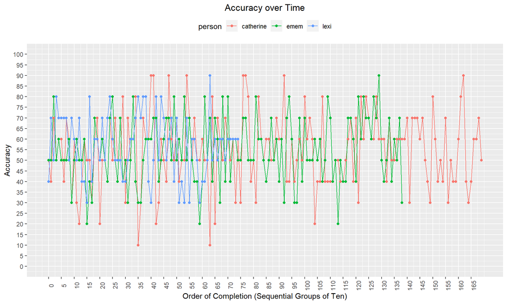

```r
# calculat results by order
human_perf_order <-
  stats_guess_full %>%
  mutate(order_tens = floor((order-1) / 10)) %>%
  mutate(outcome = case_when((predict == "truth") & (grd_truth == "truth") ~ "true_pos",
                             (predict == "truth") & (grd_truth == "lie") ~ "false_pos",
                             (predict == "lie") & (grd_truth == "lie") ~ "true_neg",
                             (predict == "lie") & (grd_truth == "truth") ~ "false_neg")) %>%
  group_by(person, order_tens, outcome) %>%
  dplyr::summarise(n = n()) %>%
  spread(key = outcome,
         value = n,
         fill = 0) %>%
  mutate(accuracy = (true_pos + true_neg) / (true_pos + true_neg + false_pos + false_neg),
         sensitivity = (true_pos) / (true_pos + false_neg),
         specificity = (true_neg) / (true_neg + false_pos),
         precision = (true_pos) / (true_pos + false_pos),
         npv = (true_neg) / (true_neg + false_neg),
         total = true_pos + true_neg + false_pos + false_neg) %>%
  filter(total == 10) %>%
  gather(key = "perf_stat",
         value = "result",
         accuracy, sensitivity, specificity, precision, npv)

# graph results
human_perf_order %>%
  filter(perf_stat == "accuracy") %>%
  ggplot(aes(x = order_tens,
             y = round(result * 100, 1),
             color = person)) +
  geom_line() +
  geom_point() +
  # geom_smooth(method = "loess") +
  scale_y_continuous(breaks = seq(from = 0, to = 100, by = 5),
                     limits = c(0, 100)) +
  scale_x_continuous(breaks = seq(from = 0, to = max(human_perf_order$order_tens), by = 5)) +
  labs(title = "Accuracy over Time",
       y = "Accuracy",
       x = "Order of Completion (Sequential Groups of Ten)") +
  theme(plot.title = element_text(hjust = 0.5),
        axis.text.x = element_text(angle = 90),
        legend.position = "top")
```

### Performance by Order (Groups of One Hundred)

The same results as above are visualized, except ordered statements have been chunked into groups of hundreds (i.e. along the x-axis is the first group of hundred statements, followed by the second group of one hundred statements, etc). Nothing extremely obvious or consistent pops out to me in this figure. There is no obvious trend in accuracy over “time”, with performance seeming to improve just as often as it declines between rounds.

(Note, that both here and in the visualization above, the final chunk graphed for each participant is the “last full chunk”. e.g. If a participant rated say 805 statements, we will see their performance across their first eight chunks of one hundred statements. We do not create a chunk for statements 800-805. The last “full chunk” is the eigth one consisting statements 700-799. (Note that chunk counting works like centuries; like the 8th century cover the years 700-799, the 8th chunk covers the statements #700-799; this is because the “first” chunk includes statements 0 to 99.))

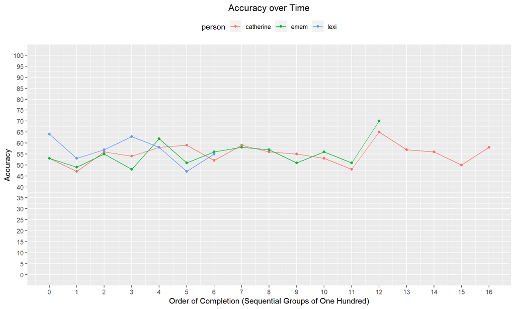

```r
# calculat results by order
human_perf_order <-
  stats_guess_full %>%
  mutate(order_hundred = floor((order-1) / 100)) %>%
  mutate(outcome = case_when((predict == "truth") & (grd_truth == "truth") ~ "true_pos",
                             (predict == "truth") & (grd_truth == "lie") ~ "false_pos",
                             (predict == "lie") & (grd_truth == "lie") ~ "true_neg",
                             (predict == "lie") & (grd_truth == "truth") ~ "false_neg")) %>%
  group_by(person, order_hundred, outcome) %>%
  dplyr::summarise(n = n()) %>%
  spread(key = outcome,
         value = n,
         fill = 0) %>%
  mutate(accuracy = (true_pos + true_neg) / (true_pos + true_neg + false_pos + false_neg),
         sensitivity = (true_pos) / (true_pos + false_neg),
         specificity = (true_neg) / (true_neg + false_pos),
         precision = (true_pos) / (true_pos + false_pos),
         npv = (true_neg) / (true_neg + false_neg),
         total = true_pos + true_neg + false_pos + false_neg) %>%
  filter(total == 100) %>%
  gather(key = "perf_stat",
         value = "result",
         accuracy, sensitivity, specificity, precision, npv)

# graph results
human_perf_order %>%
  filter(perf_stat == "accuracy") %>%
  ggplot(aes(x = order_hundred,
             y = round(result * 100, 1),
             color = person)) +
  geom_line() +
  geom_point() +
  # geom_smooth(method = "loess") +
  scale_y_continuous(breaks = seq(from = 0, to = 100, by = 5),
                     limits = c(0, 100)) +
  scale_x_continuous(breaks = seq(from = 0, to = max(human_perf_order$order_hundred), by = 1)) +
  labs(title = "Accuracy over Time",
       y = "Accuracy",
       x = "Order of Completion (Sequential Groups of One Hundred)") +
  theme(plot.title = element_text(hjust = 0.5),
        legend.position = "top")
```

# Citations

- Bond Jr, C. F., & DePaulo, B. M. (2006). Accuracy of deception judgments. Personality and social psychology Review, 10(3), 214-234.
- Levine, T. R., Park, H. S., & McCornack, S. A. (1999). Accuracy in detecting truths and lies: Documenting the “veracity effect.” Communications Monographs, 66(2), 125-144.